# Метод GET

## Два підходи до web content mining

### Робота з REST API (1 модуль)

Перший підхід полягає в безпосередній взаємодії з базою веб-ресурсу через http-запити:

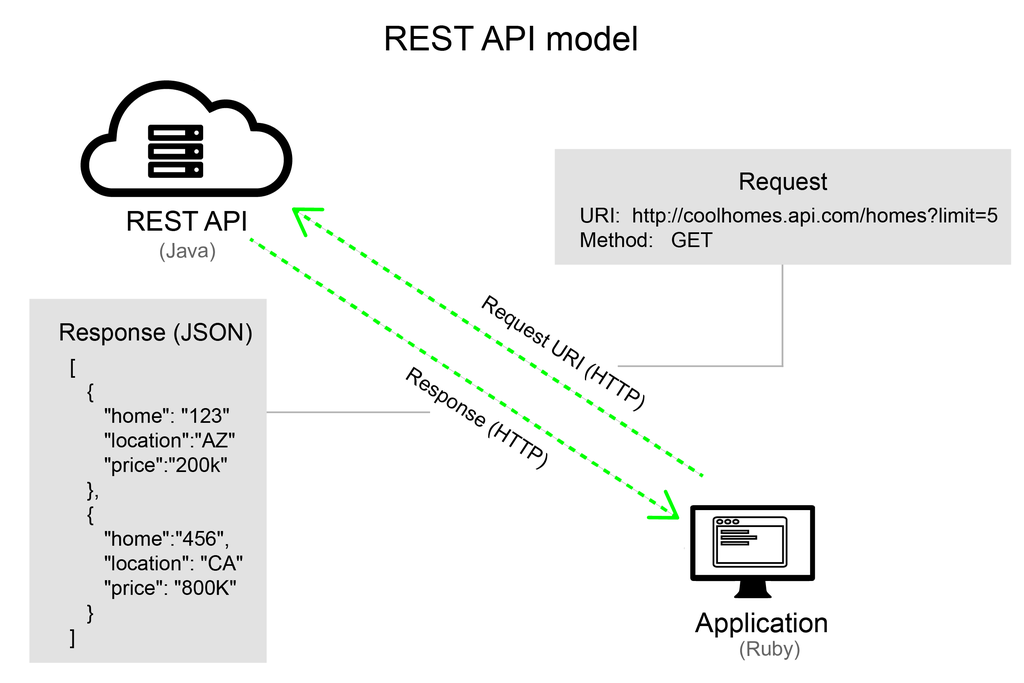

### Scraping (2 модуль)

Другий підхід складніший - ми самі відтворюємо базу через трансльований веб-контент:

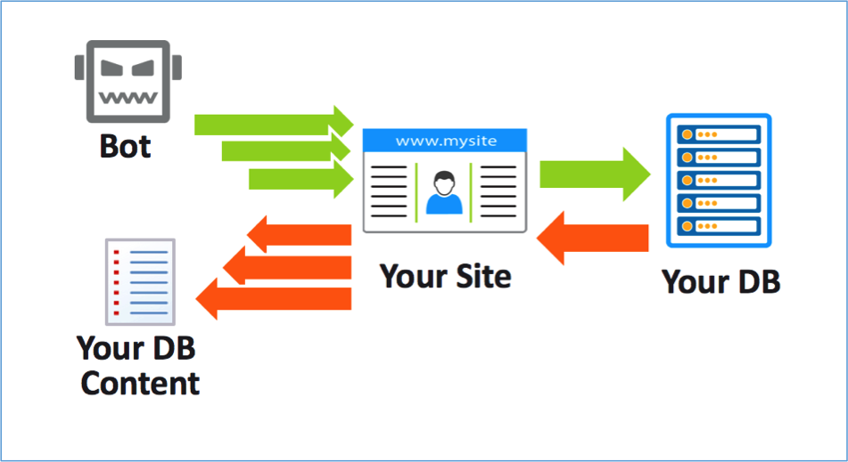

## Вступ до роботи з API

HTTP - протокол передачі гіпертексту. Це протокол для бездротових додатків для комунікації між розподіленими системами та є основою сучасної мережі.

HTTP дозволяє спілкуватися між різними хостами та клієнтами та підтримує суміш конфігурацій мережі.

Для того, щоб зробити це можливим, він припускає дуже мало про конкретну систему і не підтримує стан між різними обмінами повідомлень.

Це робить протокол HTTP незалежним. Зв’язок зазвичай проходить через TCP / IP, але можна використовувати будь-який надійний транспорт. Стандартний порт для TCP / IP - 80, але інші порти також можуть бути використані.

Користувальницькі заголовки також можуть бути створені та надіслані клієнтом.

Зв’язок між хостом і клієнтом відбувається через пару запитів / відповідей. Клієнт ініціює повідомлення про HTTP запит, який обслуговується через відповідне повідомлення HTTP.

[figure not shown]

В основі веб-комунікацій належить повідомлення про запрошення, яке надсилається через уніфіковані локатори ресурсів (URL-адреси). Я впевнений, що ви вже знайомі з URL-адресами, але для повноти я додам його тут. URL-адреси мають просту структуру, яка складається з наступних компонентів:

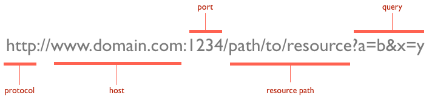

Протокол, як правило, http, але для безпечної комунікації він також може бути https. Стандартний порт складає 80, але його можна однозначно встановити, як це показано на наведеному вище зображенні. Шлях ресурсу - локальний шлях до ресурсу на сервері.

## Основні типи http-запитів

- **GET:** завантажте існуючий ресурс. URL містить всю необхідну інформацію, яку сервер повинен знайти та повернути ресурс.
- **POST:** створити новий ресурс. Запити POST зазвичай містять корисну інформацію, яка вказує дані для нового ресурсу.
- **PUT:** оновити існуючий ресурс. Корисна інформація може містити оновлені дані ресурсу.
- **DELETE:** видалити існуючий ресурс.

## Необхідні бібліотеки

В R бібліотеки встановлюються командою `install.packages("package_name")`. Викликати бібліотеку можна функцією `library`. Аналоги - `require`, `package_name::function`.

У цьому кейсі ми використаємо 3 бібліотеки (синонім - пакети):

- httr - бібліотека для виклику методів роботи з методами http (GET, POST)
- jsonlite - бібліотека для обробки json файлів
- magrittr - бібліотека, яка підключає функцію `%>%`

```r
library(httr)
library(jsonlite)
library(magrittr)
```

## Робота зі Star Wars API

Завдання: викачати базу сайту Зоряних війн. Метод роботи: GET URL: http://swapi.co/api/people/ Параметр: search

```r
str(vader)
```

```
## List of 10
##  $ url        : chr "http://swapi.co/api/people/?search=vader"
##  $ status_code: int 200
##  $ headers    :List of 13
##   ..$ date             : chr "Mon, 18 Sep 2017 12:03:44 GMT"
##   ..$ content-type     : chr "application/json"
##   ..$ transfer-encoding: chr "chunked"
##   ..$ connection       : chr "keep-alive"
##   ..$ set-cookie       : chr "__cfduid=d470deffbc465964a1d0b2793b148907a1505736224; expires=Tue, 18-Sep-18 12:03:44 GMT; path=/; domain=.swapi.co; HttpOnly"
##   ..$ etag             : chr "W/\"aeb3c302f6866c5a0a548eaafa967d61\""
##   ..$ allow            : chr "GET, HEAD, OPTIONS"
##   ..$ x-frame-options  : chr "SAMEORIGIN"
##   ..$ vary             : chr "Accept, Cookie"
##   ..$ via              : chr "1.1 vegur"
##   ..$ server           : chr "cloudflare-nginx"
##   ..$ cf-ray           : chr "3a0429e9f0a28b9a-KBP"
##   ..$ content-encoding : chr "gzip"
##   ..- attr(*, "class")= chr [1:2] "insensitive" "list"
##  $ all_headers:List of 1
##   ..$ :List of 3
##   .. ..$ status : int 200
##   .. ..$ version: chr "HTTP/1.1"
##   .. ..$ headers:List of 13
##   .. .. ..$ date             : chr "Mon, 18 Sep 2017 12:03:44 GMT"
##   .. .. ..$ content-type     : chr "application/json"
##   .. .. ..$ transfer-encoding: chr "chunked"
##   .. .. ..$ connection       : chr "keep-alive"
##   .. .. ..$ set-cookie       : chr "__cfduid=d470deffbc465964a1d0b2793b148907a1505736224; expires=Tue, 18-Sep-18 12:03:44 GMT; path=/; domain=.swapi.co; HttpOnly"
##   .. .. ..$ etag             : chr "W/\"aeb3c302f6866c5a0a548eaafa967d61\""
##   .. .. ..$ allow            : chr "GET, HEAD, OPTIONS"
##   .. .. ..$ x-frame-options  : chr "SAMEORIGIN"
##   .. .. ..$ vary             : chr "Accept, Cookie"
##   .. .. ..$ via              : chr "1.1 vegur"
##   .. .. ..$ server           : chr "cloudflare-nginx"
##   .. .. ..$ cf-ray           : chr "3a0429e9f0a28b9a-KBP"
##   .. .. ..$ content-encoding : chr "gzip"
##   .. .. ..- attr(*, "class")= chr [1:2] "insensitive" "list"
##  $ cookies    :'data.frame': 1 obs. of  7 variables:
##   ..$ domain    : chr "#HttpOnly_.swapi.co"
##   ..$ flag      : logi TRUE
```

[output cut: 9 more lines]

```
##  $ request    :List of 7
##   ..$ method    : chr "GET"
##   ..$ url       : chr "http://swapi.co/api/people/?search=vader"
##   ..$ headers   : Named chr "application/json, text/xml, application/xml, */*"
##   .. ..- attr(*, "names")= chr "Accept"
##   ..$ fields    : NULL
##   ..$ options   :List of 2
##   .. ..$ useragent: chr "libcurl/7.54.0 r-curl/2.8.1 httr/1.3.1"
##   .. ..$ httpget  : logi TRUE
##   ..$ auth_token: NULL
##   ..$ output    : list()
##   .. ..- attr(*, "class")= chr [1:2] "write_memory" "write_function"
##   ..- attr(*, "class")= chr "request"
##  $ handle     :Class 'curl_handle' <externalptr>
##  - attr(*, "class")= chr "response"
```

А тепер поглянемо на контент:

```r
vader$content
```

```
##   [1] 7b 22 63 6f 75 6e 74 22 3a 31 2c 22 6e 65 78 74 22 3a 6e 75 6c 6c 2c
##  [24] 22 70 72 65 76 69 6f 75 73 22 3a 6e 75 6c 6c 2c 22 72 65 73 75 6c 74
##  [47] 73 22 3a 5b 7b 22 6e 61 6d 65 22 3a 22 44 61 72 74 68 20 56 61 64 65
##  [70] 72 22 2c 22 68 65 69 67 68 74 22 3a 22 32 30 32 22 2c 22 6d 61 73 73
##  [93] 22 3a 22 31 33 36 22 2c 22 68 61 69 72 5f 63 6f 6c 6f 72 22 3a 22 6e
## [116] 6f 6e 65 22 2c 22 73 6b 69 6e 5f 63 6f 6c 6f 72 22 3a 22 77 68 69 74
## [139] 65 22 2c 22 65 79 65 5f 63 6f 6c 6f 72 22 3a 22 79 65 6c 6c 6f 77 22
## [162] 2c 22 62 69 72 74 68 5f 79 65 61 72 22 3a 22 34 31 2e 39 42 42 59 22
## [185] 2c 22 67 65 6e 64 65 72 22 3a 22 6d 61 6c 65 22 2c 22 68 6f 6d 65 77
## [208] 6f 72 6c 64 22 3a 22 68 74 74 70 3a 2f 2f 73 77 61 70 69 2e 63 6f 2f
## [231] 61 70 69 2f 70 6c 61 6e 65 74 73 2f 31 2f 22 2c 22 66 69 6c 6d 73 22
## [254] 3a 5b 22 68 74 74 70 3a 2f 2f 73 77 61 70 69 2e 63 6f 2f 61 70 69 2f
## [277] 66 69 6c 6d 73 2f 32 2f 22 2c 22 68 74 74 70 3a 2f 2f 73 77 61 70 69
## [300] 2e 63 6f 2f 61 70 69 2f 66 69 6c 6d 73 2f 36 2f 22 2c 22 68 74 74 70
## [323] 3a 2f 2f 73 77 61 70 69 2e 63 6f 2f 61 70 69 2f 66 69 6c 6d 73 2f 33
## [346] 2f 22 2c 22 68 74 74 70 3a 2f 2f 73 77 61 70 69 2e 63 6f 2f 61 70 69
## [369] 2f 66 69 6c 6d 73 2f 31 2f 22 5d 2c 22 73 70 65 63 69 65 73 22 3a 5b
## [392] 22 68 74 74 70 3a 2f 2f 73 77 61 70 69 2e 63 6f 2f 61 70 69 2f 73 70
## [415] 65 63 69 65 73 2f 31 2f 22 5d 2c 22 76 65 68 69 63 6c 65 73 22 3a 5b
## [438] 5d 2c 22 73 74 61 72 73 68 69 70 73 22 3a 5b 22 68 74 74 70 3a 2f 2f
## [461] 73 77 61 70 69 2e 63 6f 2f 61 70 69 2f 73 74 61 72 73 68 69 70 73 2f
## [484] 31 33 2f 22 5d 2c 22 63 72 65 61 74 65 64 22 3a 22 32 30 31 34 2d 31
## [507] 32 2d 31 30 54 31 35 3a 31 38 3a 32 30 2e 37 30 34 30 30 30 5a 22 2c
## [530] 22 65 64 69 74 65 64 22 3a 22 32 30 31 34 2d 31 32 2d 32 30 54 32 31
## [553] 3a 31 37 3a 35 30 2e 33 31 33 30 30 30 5a 22 2c 22 75 72 6c 22 3a 22
## [576] 68 74 74 70 3a 2f 2f 73 77 61 70 69 2e 63 6f 2f 61 70 69 2f 70 65 6f
## [599] 70 6c 65 2f 34 2f 22 7d 5d 7d
```

Навряд чи тут можна щось проаналізувати. Нічого страшного - це формат даних raw.

Вікіпедія дуже зрозуміло його характеризує:

> RAW (англ. raw — сирий) — формат даних, що містить необроблені (або мінімально оброблені) дані, що дозволяє уникнути втрат інформації, і не має чіткої специфікації. У таких файлах міститься повна інформація про збережений сигнал. Вихідні файли зображень (RAW) іноді називають цифровими негативами, вони виконують ту ж роль, що й негативи в плівковій фотографії: тобто, негатив не являє собою безпосередньо зображення, але має всю необхідну інформацію для створення зображення. Крім того, процес перетворення сирих файлів зображень в зрозумілому форматі іноді називають обробкою необробленого зображення, за аналогією з процесом проявлення плівки (використовуються для перетворення фотоплівки у видимі відбитки).

```r
vader$status_code
```

```
## [1] 200
```

```r
vader$headers$`content-type`
```

```
## [1] "application/json"
```

```r
names(vader)
```

```
##  [1] "url"         "status_code" "headers"     "all_headers" "cookies"
##  [6] "content"     "date"        "times"       "request"     "handle"
```

Тепер настав час отримати дані у форматі, доступному для сприйняття людиною.

```r
text_content <- content(vader, as = "text", encoding = "UTF-8")
text_content
```

```
## [1] "{\"count\":1,\"next\":null,\"previous\":null,\"results\":[{\"name\":\"Darth Vader\",\"height\":\"202\",\"mass\":\"136\",\"hair_color\":\"none\",\"skin_color\":\"white\",\"eye_color\":\"yellow\",\"birth_year\":\"41.9BBY\",\"gender\":\"male\",\"homeworld\":\"http://swapi.co/api/planets/1/\",\"…
```

Два способи перетворення json файлу

```r
parsed_content <- content(vader, as = "parsed")
names(parsed_content)
```

```
## [1] "count"    "next"     "previous" "results"
```

```r
parsed_content$count
```

```
## [1] 1
```

```r
str(parsed_content$results)
```

```
## List of 1
##  $ :List of 16
##   ..$ name      : chr "Darth Vader"
##   ..$ height    : chr "202"
##   ..$ mass      : chr "136"
##   ..$ hair_color: chr "none"
##   ..$ skin_color: chr "white"
##   ..$ eye_color : chr "yellow"
##   ..$ birth_year: chr "41.9BBY"
##   ..$ gender    : chr "male"
##   ..$ homeworld : chr "http://swapi.co/api/planets/1/"
##   ..$ films     :List of 4
##   .. ..$ : chr "http://swapi.co/api/films/2/"
##   .. ..$ : chr "http://swapi.co/api/films/6/"
##   .. ..$ : chr "http://swapi.co/api/films/3/"
##   .. ..$ : chr "http://swapi.co/api/films/1/"
##   ..$ species   :List of 1
##   .. ..$ : chr "http://swapi.co/api/species/1/"
##   ..$ vehicles  : list()
##   ..$ starships :List of 1
##   .. ..$ : chr "http://swapi.co/api/starships/13/"
##   ..$ created   : chr "2014-12-10T15:18:20.704000Z"
##   ..$ edited    : chr "2014-12-20T21:17:50.313000Z"
##   ..$ url       : chr "http://swapi.co/api/people/4/"
```

```r
parsed_content$results[[1]]$name
```

```
## [1] "Darth Vader"
```

```r
parsed_content$results[[1]]$terrain
```

[output not shown]

```r
json_content <- text_content %>% fromJSON
json_content
```

```
## $count
## [1] 1
##
## $`next`
## NULL
##
## $previous
## NULL
##
## $results
##          name height mass hair_color skin_color eye_color birth_year
## 1 Darth Vader    202  136       none      white    yellow    41.9BBY
##   gender                      homeworld
## 1   male http://swapi.co/api/planets/1/
##                                                                                                                    films
## 1 http://swapi.co/api/films/2/, http://swapi.co/api/films/6/, http://swapi.co/api/films/3/, http://swapi.co/api/films/1/
##                          species vehicles
## 1 http://swapi.co/api/species/1/     NULL
##                           starships                     created
## 1 http://swapi.co/api/starships/13/ 2014-12-10T15:18:20.704000Z
##                        edited                           url
## 1 2014-12-20T21:17:50.313000Z http://swapi.co/api/people/4/
```

```r
planetary_data <- json_content$results
names(planetary_data)
```

```
##  [1] "name"       "height"     "mass"       "hair_color" "skin_color"
##  [6] "eye_color"  "birth_year" "gender"     "homeworld"  "films"
## [11] "species"    "vehicles"   "starships"  "created"    "edited"
## [16] "url"
```

```r
planetary_data$name
```

```
## [1] "Darth Vader"
```

```r
planetary_data$terrain
```

[output not shown]

```r
json_parse <- function(req) {
  text <- content(req, as = "text", encoding = "UTF-8")
  if (identical(text, "")) warn("No output to parse.")
  fromJSON(text)
}
```

```r
planets <- GET("http://swapi.co/api/planets") %>% stop_for_status()
json_planets <- json_parse(planets)
```

```r
names(json_planets)
```

```
## [1] "count"    "next"     "previous" "results"
```

```r
json_planets$count
```

```
## [1] 61
```

```r
length(json_planets$results$name)
```

```
## [1] 10
```

```r
json_planets$`next`
```

```
## [1] "http://swapi.co/api/planets/?page=2"
```

```r
swapi_planets <- json_planets$results
swapi_planets$name
```

```
##  [1] "Alderaan"  "Yavin IV"  "Hoth"      "Dagobah"   "Bespin"
##  [6] "Endor"     "Naboo"     "Coruscant" "Kamino"    "Geonosis"
```

```r
next_page <- GET(json_planets$`next`) %>% stop_for_status()
```

```r
parsed_next_page <- json_parse(next_page)
parsed_next_page$results$name
```

```
##  [1] "Utapau"         "Mustafar"       "Kashyyyk"       "Polis Massa"
##  [5] "Mygeeto"        "Felucia"        "Cato Neimoidia" "Saleucami"
##  [9] "Stewjon"        "Eriadu"
```

```r
planets <- GET("http://swapi.co/api/planets") %>%
  stop_for_status() %>%
  json_parse
swapi_planets <- planets$results
```

```r
next_page <- planets$`next`
while(!is.null(next_page)) {
  more_planets <- GET(next_page) %>%
    stop_for_status() %>%
    json_parse
  swapi_planets <- rbind(swapi_planets, more_planets$results)
  next_page <- more_planets$`next`
}
```

```r
length(swapi_planets$name)
```

```
## [1] 61
```

```r
swapi_planets$name
```

```
##  [1] "Alderaan"       "Yavin IV"       "Hoth"           "Dagobah"
##  [5] "Bespin"         "Endor"          "Naboo"          "Coruscant"
##  [9] "Kamino"         "Geonosis"       "Utapau"         "Mustafar"
## [13] "Kashyyyk"       "Polis Massa"    "Mygeeto"        "Felucia"
## [17] "Cato Neimoidia" "Saleucami"      "Stewjon"        "Eriadu"
## [21] "Corellia"       "Rodia"          "Nal Hutta"      "Dantooine"
## [25] "Bestine IV"     "Ord Mantell"    "unknown"        "Trandosha"
## [29] "Socorro"        "Mon Cala"       "Chandrila"      "Sullust"
## [33] "Toydaria"       "Malastare"      "Dathomir"       "Ryloth"
## [37] "Aleen Minor"    "Vulpter"        "Troiken"        "Tund"
## [41] "Haruun Kal"     "Cerea"          "Glee Anselm"    "Iridonia"
## [45] "Tholoth"        "Iktotch"        "Quermia"        "Dorin"
## [49] "Champala"       "Mirial"         "Serenno"        "Concord Dawn"
## [53] "Zolan"          "Ojom"           "Skako"          "Muunilinst"
## [57] "Shili"          "Kalee"          "Umbara"         "Tatooine"
## [61] "Jakku"
```